# Reproducible Research: Peer Assessment 1

## Loading and preprocessing the data

```r
setwd("C://Users/demyc 13/Documents/Geovanni/Coursera (Data Science)/5. Reproducible Research/Week 1/Project 1")
library(dplyr)
library(lubridate)
library(lattice)
```

## What is mean total number of steps taken per day?

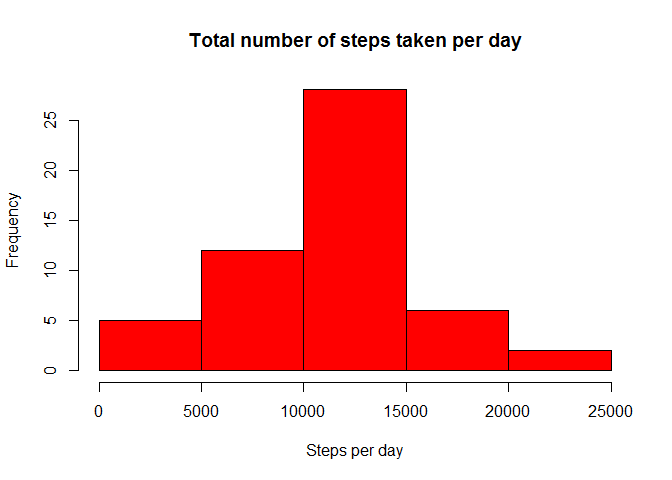

```r
# Select only the complete cases (without NA's)
data<-read.csv("activity.csv", header=TRUE, colClasses=c("numeric", "Date","numeric"))
cc<-data[complete.cases(data),]
# Calculate the total number steps per day
steps_day<-group_by(cc,date)%>% summarise(stepsday=sum(steps))
# Plot the histogram
hist(steps_day$stepsday,xlab="Steps per day",main="Total number of steps taken per day",col="red")
```

```r
dev.copy(png,file="plot1.png")
```

```r
dev.off()
```

```r
# Calculate the media and the median of the total number of steps taken per day
mean(steps_day$stepsday)
```

```
## [1] 10766.19
```

```r
median(steps_day$stepsday)
```

```
## [1] 10765
```

The mean total number of steps taken per day is 10,766 and the median is 10,765.

## What is the average daily activity pattern?

First calculate average steps for each interval for all days

```r
# Calculate average steps
steps_interval<-group_by(cc,interval)%>% summarise(stepsint=mean(steps))
```

Then plot the average steps by interval.

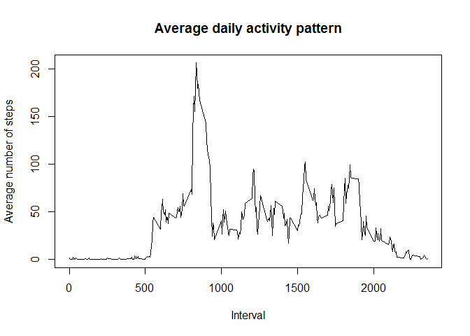

```r
plot(stepsint~interval,data=steps_interval,type="l",xlab="Interval",ylab="Average number of steps",main="Average daily activity pattern")
```

```r
dev.copy(png,file="plot2.png")
```

```r
dev.off()
```

Now, find the interval with most steps.

```r
max_steps<-steps_interval[steps_interval$stepsint==max(steps_interval$stepsint),1]
max_steps
```

```
## [1] 835
```

The interval with most steps is 835

## Imputing missin values

Calculate the number missing values in the dataset.

```r
# Filter the rows with missing values
missing<-data[!complete.cases(data),]
nrow(missing)
```

```
## [1] 2304
```

The number of missing values in the dataset is 2304.

```r
# Calculate the mean of total number steps per day for replace the missing data
steps_day<- aggregate(steps ~ interval, data = data, FUN = median)
r_data<-numeric()
for (i in 1:nrow(data)) {
    ind <- data[i, ]
    if (is.na(ind$steps)) {
        steps <- subset(steps_day, interval == ind$interval)$steps
    } else {
        steps <- ind$steps
    }
    r_data <- c(r_data, steps)
}
```

Create a new dataset with imputed data

```r
complete_data<-data
complete_data$steps<-r_data
```

Contruct the histogram with the new dataset and recalculate the mean and the median.

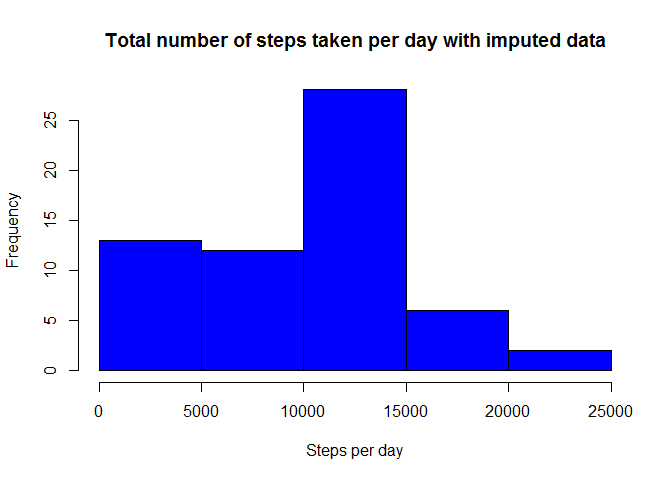

```r
idsteps_day<-group_by(complete_data,date)%>% summarise(stepsday=sum(steps))
hist(idsteps_day$stepsday,xlab="Steps per day",main="Total number of steps taken per day with imputed data",col="blue")
```

```r
dev.copy(png,file="plot3.png")
```

```r
dev.off()
```

```r
# Calculate the media and the median of the total number of steps taken per day
mean(idsteps_day$stepsday)
```

```
## [1] 9503.869
```

```r
median(idsteps_day$stepsday)
```

```
## [1] 10395
```

## Are there differences in activity patterns between weekdays and weekends?

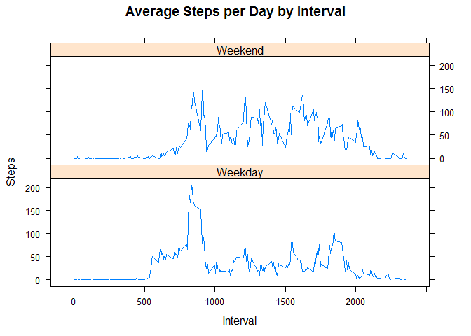

```r
# Classifying days
days <- c("lunes", "martes","miércoles", "jueves", "viernes")
complete_data$week <- as.factor(ifelse(is.element(weekdays(complete_data$date),days), "Weekday", "Weekend"))
# Calculate the average of steps by interval and type the day
steps_total<-group_by(complete_data,interval,week)%>% summarise(steps=mean(steps))
xyplot(steps_total$steps ~ steps_total$interval|steps_total$week, main="Average Steps per Day by Interval",xlab="Interval", ylab="Steps",layout=c(1,2), type="l")
```

```r
dev.copy(png,file="plot4.png")
```

```r
dev.off()
```